MapBiomas Fuego · Argentina · Colección 1

# Magma o rocket

Fondo medio y sin sombra, ya fijos. Con los cambios pedidos: se fueron las preguntas del margen y las notas de resolución, la tipografía subió dos puntos y el bloque entero corrió hacia arriba, así que la banda de productos ya no toca el borde.

[figure not shown]

## Una al lado de la otra

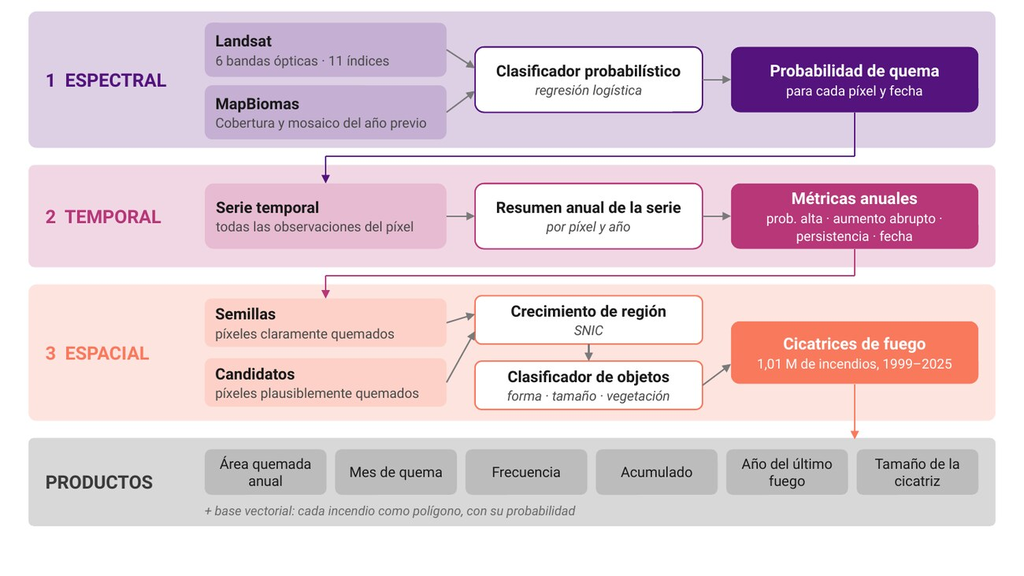

magma · #54137D #B73779 #F9795D

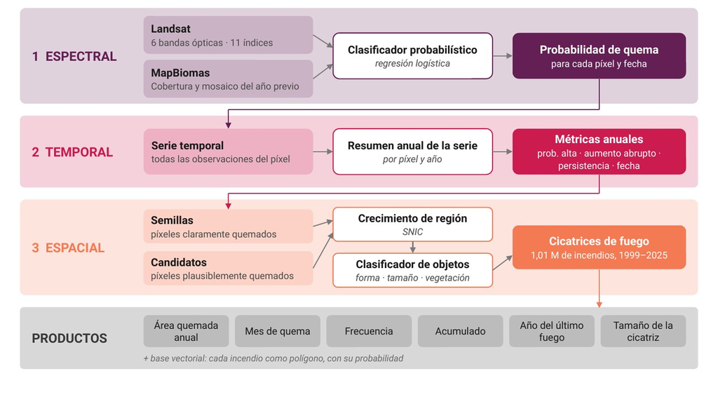

rocket · #641F54 #CB1B4F #F47A54

## En qué se diferencian, concretamente

- →**La etapa 2 es la que decide.** En magma es `#B73779`, un magenta que tira a violeta; en rocket es `#CB1B4F`, un carmín que tira a rojo. Todo lo demás está a pocos grados de distancia.
- →**Rocket hace puente con la carátula.** Su carmín es lo más cerca que llega una paleta de la familia magma al rojo de MapBiomas Fuego, sin ser el rojo corporativo.
- →**Magma es la del factsheet.** La Fig 01, el mapa de cantidad de años quemados, es magma. Si las figuras entran al deck sin retocar, magma las acompaña sin una segunda familia de color en escena.
- →**Magma separa más las tres etapas** —el violeta arranca más frío y más oscuro—, y rocket se lee más cálido y más parejo, más «fuego» y menos «escala».